# Project

# Summary

Using the weight lifting dataset from http://groupware.les.inf.puc-rio.br (ref: Qualitative Activity Recognition of Weight Lifting Exercises), we analyzed 6 individuals conducting various exercises. Using a random forest based prediction algorithm, we can predict with 99% accuracy if they are doing the exercise the right way, or if not, the type of mistake they are making.

# Getting data

Original testing (cross validation) data is not enough.  
We have decided to use training set only and ignore the testing data

```r
# Download and read the training set
# but skip it if it already exists
#setwd("/Users/daghan/Dropbox (Personal)/personal/Hacking/Coursera/Data Science/Practical Machine Learning/Project")
setwd("/Users/daghan/Hacking/Coursera/Data Science/Practical Machine Learning/Project")
if (!file.exists("./pml-training.csv")){
    download.file("https://d396qusza40orc.cloudfront.net/predmachlearn/pml-training.csv", "./pml-training.csv", method="curl")
} else {
    print("skipping download, training file exists already")
}

if (!file.exists("./pml-testing.csv")){
    download.file("https://d396qusza40orc.cloudfront.net/predmachlearn/pml-testing.csv", "./pml-testing.csv", method="curl")
} else {
    print("skipping download, testing file exists already")
}

pml <- read.csv("pml-training.csv")
testing_coursera <- read.csv("pml-testing.csv")
```

# Exploratory data analysis

The outcome (pml$classe) is a factor variable with 5 possible outcomes

```r
summary(pml$classe)
```

```
##    A    B    C    D    E
## 5580 3797 3422 3216 3607
```

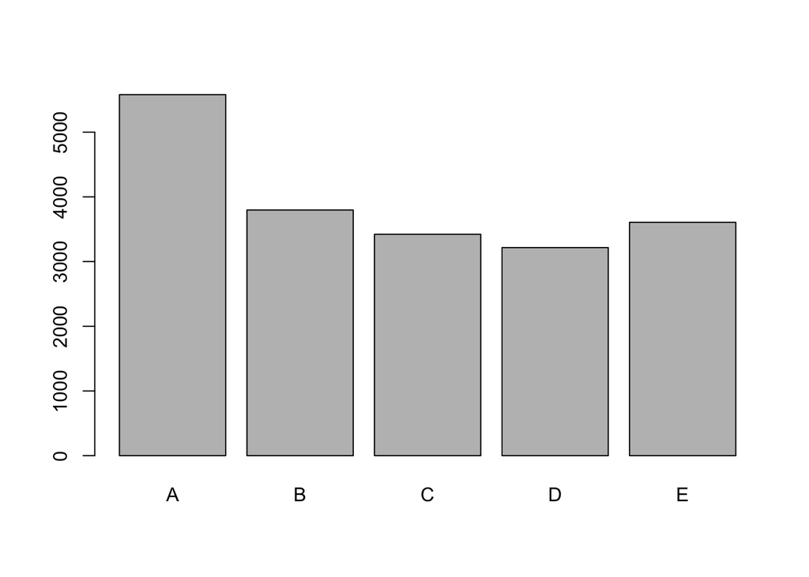

```r
barplot(summary(pml$classe))
```

It is a classification problem and since it has more than 2 levels, we can’t use logical regression.  
Instead we’ll use a random forest based classification algorithm.

# Cleaning the data

```r
# there are a ton of NAs in the final testing data
naCols <- sapply(testing_coursera, function(x)all(is.na(x)))
pml1<- pml[,naCols == FALSE]

pml2 <- pml1[,c(-1,-2,-3,-4, -5)]

# getting rid of the near zero variance values
nzv <- nearZeroVar(pml2, saveMetrics=TRUE)
pml3 <- pml2[, nzv$nzv==FALSE]

# reduced these many columns
 (dim(pml) - dim(pml3))[2]
```

```
## [1] 106
```

# Splicing the data to training and testing sets

There wasn’t enough testing examples in the original test set (only 20 unique values, we typically need 25% ~ 40%). We have decided to split the training set to training(75%) and testing (25%)

```r
# split to training and test
inTrain = createDataPartition(pml3$classe, p = 3/4)[[1]]
training = pml3[ inTrain,]
testing = pml3[-inTrain,]
training$classe <- as.factor(training$classe)
testing$classe <- as.factor(testing$classe)
```

# Training the model

We can have an additional preprocessing step, where we reduce the input data to its principal components, using PCA, but for now we’ll skip it to see what accuracy we get with the base line data.

```r
# now we can train a randomForest based classifier
rf <- randomForest(training[,-54], training$classe, ntree = 300)
```

# Prediction

We’ll use the model we have trained to predict the outcome for both the training and the testing sets

```r
# let's get a prediction on the testing set using the model
predTraining <- predict(rf, training[,-54])
predTesting<- predict(rf, testing[,-54])
```

# Accuracy

We’ll now test the accuracy of our predictions against the actual data to determine in-sample and out-of-sample error rates

```r
# how well did we do?
cmTraining <- confusionMatrix(predTraining, training$classe)
cmTesting <- confusionMatrix(predTesting, testing$classe)
cmTesting$table
```

```
##           Reference
## Prediction    A    B    C    D    E
##          A 1395    0    0    0    0
##          B    0  949    1    0    0
##          C    0    0  854    9    0
##          D    0    0    0  795    1
##          E    0    0    0    0  900
```

## In-sample error

```r
cmTraining$overall
```

```
##       Accuracy          Kappa  AccuracyLower  AccuracyUpper   AccuracyNull
##         1.0000         1.0000         0.9997         1.0000         0.2843
## AccuracyPValue  McnemarPValue
##         0.0000            NaN
```

## Out-of-sample error

```r
cmTesting$overall
```

```
##       Accuracy          Kappa  AccuracyLower  AccuracyUpper   AccuracyNull
##         0.9978         0.9972         0.9960         0.9989         0.2845
## AccuracyPValue  McnemarPValue
##         0.0000            NaN
```

# Conclusion

We are 99.78% accurate.